# Genesis NFgenes assembly: Main frame

Sebastian Hesse [Dr.Basi]

1/27/2022

Here we assemble the data for the genesis mint main frame. We aim for it to contain for each gene: - gene symbol - gene name - gene ID - length - chromosomal location

# 1 NCBI data import

Downloaded gff3 file (RefSeq Reference Genome Annotation) from https://www.ncbi.nlm.nih.gov/genome/guide/human/#download at 24.01.22.

Overview of the data: https://www.ncbi.nlm.nih.gov/genome/annotation_euk/Homo_sapiens/109.20211119/

## 1.1 Import and cleanup

```r
## import functions for gff format from https://support.bioconductor.org/p/24657/

# function to import gff file
gffRead <- function(gffFile, nrows = -1) {
     cat("Reading ", gffFile, ": ", sep="")
     gff = read.table(gffFile, sep="\t", as.is=TRUE, quote="",
     header=FALSE, comment.char="#", nrows = nrows,
     colClasses=c("character", "character", "character", "integer",
"integer",
     "character", "character", "character", "character"))
     colnames(gff) = c("seqname", "source", "feature", "start", "end",
             "score", "strand", "frame", "attributes")
     cat("found", nrow(gff), "rows with classes:",
         paste(sapply(gff, class), collapse=", "), "\n")
     stopifnot(!anyNA(gff$start), !anyNA(gff$end))
     return(gff)
}

# fct to split attributes
getAttributeField <- function (x, field, attrsep = ";") {
     s = strsplit(x, split = attrsep, fixed = TRUE)
     sapply(s, function(atts) {
         a = strsplit(atts, split = "=", fixed = TRUE)
         m = match(field, sapply(a, "[", 1))
         if (!is.na(m)) {
             rv = a[[m]][2]
         }
         else {
             rv = as.character(NA)
         }
         return(rv)
     })
}


# parts below are computer intensive. End result was saved and is re-loaded below

# # import NCBI (load compiled csv from below!)
# NCBI_raw <- gffRead("/Users/sebastianhesse/Documents/NFT_projects/NFgenes/R_files/raw_data/GRCh38_latest_genomic.gff")
#
# # reduce to genes (rest are other genome regions)
# NCBI_raw_genes <- NCBI_raw %>% filter(feature == "gene")
#
# # dissect attributes
# NCBI_raw_genes$id_symbol_primary2 <- getAttributeField(NCBI_raw_genes$attributes, "ID") # many strange dashes that dont belong to the symbol. make secondary
# NCBI_raw_genes$Ref <- getAttributeField(NCBI_raw_genes$attributes, "Dbxref")
# NCBI_raw_genes$id_symbol_primary <- getAttributeField(NCBI_raw_genes$attributes, "Name") # clean symbols, use as primary!
# NCBI_raw_genes$gbkey <- getAttributeField(NCBI_raw_genes$attributes, "gbkey")
# NCBI_raw_genes$id_symbol_primary3 <- getAttributeField(NCBI_raw_genes$attributes, "gene")
# NCBI_raw_genes$type_biotype <- getAttributeField(NCBI_raw_genes$attributes, "gene_biotype")
# NCBI_raw_genes$id_symbol_alias <- getAttributeField(NCBI_raw_genes$attributes, "gene_synonym")
# NCBI_raw_genes$id_protein_name <- getAttributeField(NCBI_raw_genes$attributes, "description")
#
# ## clean cols
# NCBI_raw_genes$id_symbol_primary <- gsub("^[^:]*gene-", "", NCBI_raw_genes$id_symbol_primary)
#
# NCBI_raw_genes <- NCBI_raw_genes %>% separate(Ref, c("id_geneID", 'id_HGNC', 'id_miRBase'), ",")
# NCBI_raw_genes$id_geneID <- gsub("^[^:]*GeneID:", "", NCBI_raw_genes$id_geneID)
# NCBI_raw_genes$id_HGNC <- gsub("^[^:]*HGNC:HGNC:", "", NCBI_raw_genes$id_HGNC)
# NCBI_raw_genes$id_miRBase <- gsub("^[^:]*miRBase:", "", NCBI_raw_genes$id_miRBase)
#
# # clear MIM (OMIM ID) in miRBase field and add to own MIM_id col
# NCBI_raw_genes$id_MIM <- NA
# NCBI_raw_genes$id_MIM <- ifelse(str_detect(NCBI_raw_genes$id_miRBase, "MIM"), NCBI_raw_genes$id_miRBase, NA)
# NCBI_raw_genes$id_miRBase <- ifelse(str_detect(NCBI_raw_genes$id_miRBase, "MIM"), NA, NCBI_raw_genes$id_miRBase)
# NCBI_raw_genes$id_MIM <- gsub("MIM:", "", NCBI_raw_genes$id_MIM)
#
# NCBI_preped <- NCBI_raw_genes
#
# # save copy and reload
# write_csv(NCBI_preped, "/Users/sebastianhesse/Documents/NFT_projects/NFgenes/R_files/compiled_data/NCBI_preped.csv")

NCBI_preped <- read_csv("/Users/sebastianhesse/Documents/NFT_projects/NFgenes/R_files/compiled_data/NCBI_preped.csv")
```

## 1.2 Chromosomes

NC_ ids are easily coded for the chromosome:

NC_000001.11: chr1, NC_000002.12: chr2, …, NC_000023.11: chrX, NC_000024.10:chrY, NC_012920.1: chrM

But there are many non-standard annotated genes we will need to take care of as well.

```r
# format standard annotated chromosomes
NCBI_preped$chromosome <- NA
NCBI_preped$chromosome <- ifelse(str_detect(NCBI_preped$seqname, "NC_"), NCBI_preped$seqname, NA)
NCBI_preped$chromosome <- gsub("^[^:]*NC_00000", "", NCBI_preped$chromosome)
NCBI_preped$chromosome <- gsub("^[^:]*NC_0000", "", NCBI_preped$chromosome)
NCBI_preped$chromosome <- gsub("\\..*","",NCBI_preped$chromosome)
NCBI_preped$chromosome <- ifelse(str_detect(NCBI_preped$seqname, "NC_012920"), "mito", NCBI_preped$chromosome) # NC_012920 is the mitochondrial genome
NCBI_preped$chromosome <- ifelse(str_detect(NCBI_preped$seqname, "NC_012920"), "mito", NCBI_preped$chromosome)
NCBI_preped %<>% mutate(chromosome = ifelse(chromosome == 23, "X", NCBI_preped$chromosome))
NCBI_preped %<>% mutate(chromosome = ifelse(chromosome == 24, "Y", NCBI_preped$chromosome))


## check for NA

paste0("Are there any genes with missing chomosome information?")
```

```
## [1] "Are there any genes with missing chomosome information?"
```

```r
anyNA(NCBI_preped$chromosome) # there are non standard NC annotated gene regions
```

```
## [1] TRUE
```

```r
paste0("How many genes are missing chomosome information?")
```

```
## [1] "How many genes are missing chomosome information?"
```

```r
NCBI_preped %>% filter(is.na(chromosome)) %>% nrow()
```

```
## [1] 4935
```

```r
# isolate
NCBI_non_NC_chromosomes <- NCBI_preped %>% filter(is.na(chromosome))

paste0("Which types of genes are missing chomosome information?")
```

```
## [1] "Which types of genes are missing chomosome information?"
```

```r
table(NCBI_non_NC_chromosomes$type_biotype)
```

```
##
##  antisense_RNA       C_region      D_segment      J_segment         lncRNA
##              1             11             29             19           1383
##          miRNA       misc_RNA          ncRNA          other protein_coding
##            204             17              2             14           2884
##           rRNA         snoRNA          snRNA           tRNA      V_segment
##             33             48              1            161            128
```

```r
paste0("As there are too many now and no clear solution, we will take care of protein coding genes with missing chomosome info below.")
```

```
## [1] "As there are too many now and no clear solution, we will take care of protein coding genes with missing chomosome info below."
```

For the future, there is an initiative to resolve the problem of multiple accessions by using a “Universal Genomic Accession Hash (UGAHash)”. We can read into this at a later time point and maybe include this into NFgenes: https://academic.oup.com/bib/article/18/2/226/2453279

# 2 Protein coding genes

## 2.1 Quality check

```r
NCBI_prot <- NCBI_preped %>% filter(type_biotype == "protein_coding")

## format
# col_classes(NCBI_prot)
NCBI_prot$id_geneID <- as.factor(NCBI_prot$id_geneID)

## cleanup names

## check

# SYMBOLS
paste0("Are there any NA in the NCBI primary symbols?")
```

```
## [1] "Are there any NA in the NCBI primary symbols?"
```

```r
anyNA(NCBI_prot$id_symbol_primary) # no NAs
```

```
## [1] FALSE
```

```r
# duplicates
paste0("Are there any duplicates in the NCBI primary symbols?")
```

```
## [1] "Are there any duplicates in the NCBI primary symbols?"
```

```r
anyDuplicated(NCBI_prot$id_symbol_primary) # 19430 duplicates in symbols! The duplicates do not have a chromosome number and seem to be random double entries. Check gene_id first
```

```
## [1] 19430
```

```r
# GENE ID
NCBI_prot[duplicated(NCBI_prot$id_geneID),] #there are 2815 duplicated gene IDs! Inspect
```

```
## # A tibble: 2,815 × 21
##    seqname      source  feature   start    end score strand frame attributes
##    <chr>        <chr>   <chr>     <dbl>  <dbl> <chr> <chr>  <chr> <chr>
##  1 NC_000024.10 BestRe… gene     276356 3.03e5 .     +      .     ID=gene-PLCXD…
##  2 NC_000024.10 BestRe… gene     303352 3.19e5 .     -      .     ID=gene-GTPBP…
##  3 NC_000024.10 BestRe… gene     333933 3.87e5 .     -      .     ID=gene-PPP2R…
##  4 NC_000024.10 BestRe… gene     624344 6.59e5 .     +      .     ID=gene-SHOX-…
##  5 NC_000024.10 BestRe… gene    1190437 1.21e6 .     -      .     ID=gene-CRLF2…
##  6 NC_000024.10 BestRe… gene    1268814 1.33e6 .     +      .     ID=gene-CSF2R…
##  7 NC_000024.10 BestRe… gene    1336574 1.38e6 .     +      .     ID=gene-IL3RA…
##  8 NC_000024.10 BestRe… gene    1386152 1.39e6 .     -      .     ID=gene-SLC25…
##  9 NC_000024.10 Gnomon  gene    1392349 1.40e6 .     +      .     ID=gene-LOC10…
## 10 NC_000024.10 BestRe… gene    1403139 1.45e6 .     -      .     ID=gene-ASMTL…
## # … with 2,805 more rows, and 12 more variables: id_symbol_primary2 <chr>,
## #   id_geneID <fct>, id_HGNC <chr>, id_miRBase <chr>, id_symbol_primary <chr>,
## #   gbkey <chr>, id_symbol_primary3 <chr>, type_biotype <chr>,
## #   id_symbol_alias <chr>, id_protein_name <chr>, id_MIM <dbl>,
## #   chromosome <chr>
```

```r
duplicates_GeneID_NCBI <- NCBI_prot[duplicated(NCBI_prot$id_geneID),] #all of these genes are copies of already included genes. Also, they do not have a chromosome info or ocnflicting chromosome info that does not match with the gene cards entry. Remove!
# nrow(duplicates_GeneID_NCBI) #ok

# to remove them we will use the id_symbol_primary2 as these are unique. This will remove all duplicates

NCBI_prot_unique <- NCBI_prot %>% filter(! id_symbol_primary2 %in% duplicates_GeneID_NCBI$id_symbol_primary2)

## check duplicates
anyDuplicated(NCBI_prot_unique$id_geneID) # no duplicate IDs!
```

```
## [1] 0
```

```r
anyDuplicated(NCBI_prot_unique$id_symbol_primary) # no duplicate symbols!
```

```
## [1] 0
```

```r
anyDuplicated(NCBI_prot_unique$id_protein_name) # 4 duplicates in protein names
```

```
## [1] 4
```

```r
anyNA(NCBI_prot_unique$id_protein_name) # also NA
```

```
## [1] TRUE
```

```r
## check protein names
NCBI_prot_protNameDups <- NCBI_prot_unique %>% filter(! is.na(id_protein_name)) %>% filter(duplicated(id_protein_name))

# Morf4 family associated protein 1 like 1: duplicate is a LOC gene -> will be removed
# zinc finger and SCAN domain containing 29: dup is LOC gene
# TP53-target gene 3 protein: both are LOC genes.
# cancer/testis antigen family 47 member A11: dup is LOC gene

# -> all dups will be removed via removal of LOCs

# some protein names have "%" instead of -. Exchange
NCBI_prot_unique$id_protein_name <- gsub("%" ,"-", NCBI_prot_unique$id_protein_name)

# make first letter upper but keep all upper part of names
NCBI_prot_unique$id_protein_name <-  str_replace(NCBI_prot_unique$id_protein_name, "^\\w{1}", toupper)


## Genes without proper symbols

# remove LOC and ORF (= putative genes without biological info)
Nr_LOC_in_NCBI <- sum(str_detect(NCBI_prot_unique$id_symbol_primary, "LOC[:digit:][:digit:][:digit:]"))
Nr_LOC_in_NCBI # 250 LOCs
```

```
## [1] 250
```

```r
Nr_ORF_in_NCBI <- sum(str_detect(NCBI_prot_unique$id_symbol_primary, "orf"))
Nr_ORF_in_NCBI # 267 ORFs
```

```
## [1] 267
```

```r
# extract symbols of LOC and ORF and remove
LOC_in_NCBI <- NCBI_prot_unique %>% filter(str_detect(id_symbol_primary, 'LOC[:digit:][:digit:][:digit:]')) %>% pull(id_symbol_primary)
# contains some readthroughwith unknown function. OK to remove

ORF_in_NCBI <- NCBI_prot_unique %>% filter(str_detect(id_symbol_primary, 'orf')) %>% pull(id_symbol_primary)
# contains some readthroughwith unknown function. OK to remove

NCBI_prot_unique_noLOCnoORF <- NCBI_prot_unique %>% filter(! id_symbol_primary %in% c(LOC_in_NCBI, ORF_in_NCBI))

# remove LOC and ORF genes
NCBI_prot_prefinal <- NCBI_prot_unique_noLOCnoORF %>% select(id_symbol_primary, id_protein_name, id_geneID, chromosome, start, end, strand)
```

## 2.2 Add missing data

```r
## check missing in prefinal data
missing_protcoding_cols <- apply(NCBI_prot_prefinal, 2, function(x) any(is.na(x) | is.infinite(x)))
paste0("Are there any information missing in the prefinal gene list?")
```

```
## [1] "Are there any information missing in the prefinal gene list?"
```

```r
missing_protcoding_cols
```

```
## id_symbol_primary   id_protein_name         id_geneID        chromosome
##             FALSE              TRUE             FALSE              TRUE
##             start               end            strand
##             FALSE             FALSE             FALSE
```

```r
paste0("Some are missing a protein name, some are missing a chomosome.")
```

```
## [1] "Some are missing a protein name, some are missing a chomosome."
```

```r
# subset
NCBI_prot_NA_protName <- NCBI_prot_prefinal %>% filter(is.na(id_protein_name))

NCBI_prot_NA_Chromosome <- NCBI_prot_prefinal %>% filter(is.na(chromosome))


NCBI_prot_NA_protName_allinfo <- NCBI_prot_prefinal %>% filter(id_geneID %in% NCBI_prot_NA_protName$id_geneID)

NCBI_prot_NA_Chromosome_allInfo <- NCBI_prot_prefinal %>% filter(id_geneID %in% NCBI_prot_NA_Chromosome$id_geneID)

## get info from manual search

# chromosome
# write_clip(NCBI_prot_NA_Chromosome$id_symbol_primary)
# https://docs.google.com/spreadsheets/d/1hpIE8RX4W9MYYYfFLzONBkf13oWkeRiiHboMFQyi9pk/edit?usp=sharing
manual_chomosomes_NCBI <-  read_csv("/Users/sebastianhesse/Documents/NFT_projects/NFgenes/R_files/raw_data/missing_chomosomes.csv")

# protein name
# write_clip(NCBI_prot_NA_protName_allinfo$id_symbol_primary)
# https://docs.google.com/spreadsheets/d/1r4fwurJvY6p1yKtNimyPJPlMoN1Xa8d0I4xjvdTg0A8/edit?usp=sharing
manual_protNames_NCBI <- read_csv("/Users/sebastianhesse/Documents/NFT_projects/NFgenes/R_files/raw_data/missing_protein_name_NCBI_02_2022 - Tabellenblatt1(3).csv")

paste0("All missing data could be added via https://www.genecards.org")
```

```
## [1] "All missing data could be added via https://www.genecards.org"
```

```r
# add data
NCBI_prot_prefinal_added <- NCBI_prot_prefinal %>% left_join(manual_protNames_NCBI, by= c("id_symbol_primary" = 'id_symbol'))

NCBI_prot_prefinal_added <- NCBI_prot_prefinal_added %>% left_join(manual_chomosomes_NCBI, by= c("id_symbol_primary" = 'id_symbol'))

## concatenate
#format
NCBI_prot_prefinal_added$chromosome.y <- as.factor(NCBI_prot_prefinal_added$chromosome.y)
NCBI_prot_prefinal_added$chromosome.x <- as.factor(NCBI_prot_prefinal_added$chromosome.x)

NCBI_prot_prefinal_clean <- NCBI_prot_prefinal_added %>%
  mutate(id_protein_name = coalesce(
  id_protein_name.x,
  id_protein_name.y)) %>%
  mutate(chromosome = coalesce(
  chromosome.x,
  chromosome.y)) %>%
         select(- c(id_protein_name.x, id_protein_name.y, chromosome.x, chromosome.y))


## check NA
missing_NCBI_prefinal_clean <- apply(NCBI_prot_prefinal_clean, 2, function(x) any(is.na(x) | is.infinite(x)))
paste0("Are there any information missing in the prefinal gene list?")
```

```
## [1] "Are there any information missing in the prefinal gene list?"
```

```r
missing_NCBI_prefinal_clean
```

```
## id_symbol_primary         id_geneID             start               end
##             FALSE             FALSE             FALSE             FALSE
##            strand   id_protein_name        chromosome
##             FALSE             FALSE             FALSE
```

```r
paste0("Some are no missing data in the manually curated NCBI gene list.")
```

```
## [1] "Some are no missing data in the manually curated NCBI gene list."
```

```r
## add length
NCBI_prot_prefinal_clean$length <- NCBI_prot_prefinal_clean$end - NCBI_prot_prefinal_clean$start

NCBI_prot_final <- NCBI_prot_prefinal_clean
```

## 2.3 Analysis

```r
# Number of protein coding genes
NCBI_prot_nr <- NCBI_prot_final %>% nrow()

paste("From NCBI we collected the data of", NCBI_prot_nr, "unique protein coding genes with protein names and defined gene location (chromosome, start, end, length, strand)" )
```

```
## [1] "From NCBI we collected the data of 19041 unique protein coding genes with protein names and defined gene location (chromosome, start, end, length, strand)"
```

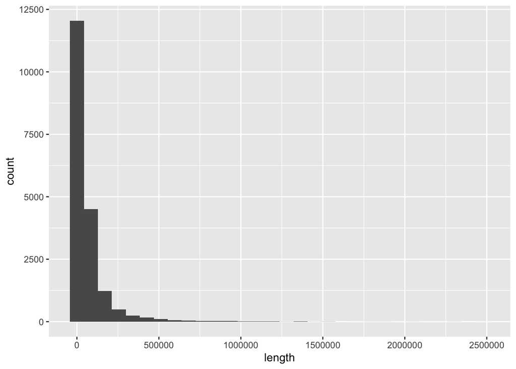

```r
## histograms

# gene length
NCBI_prot_final %>%
   ggplot(aes(x= length)) +
   geom_histogram()
```

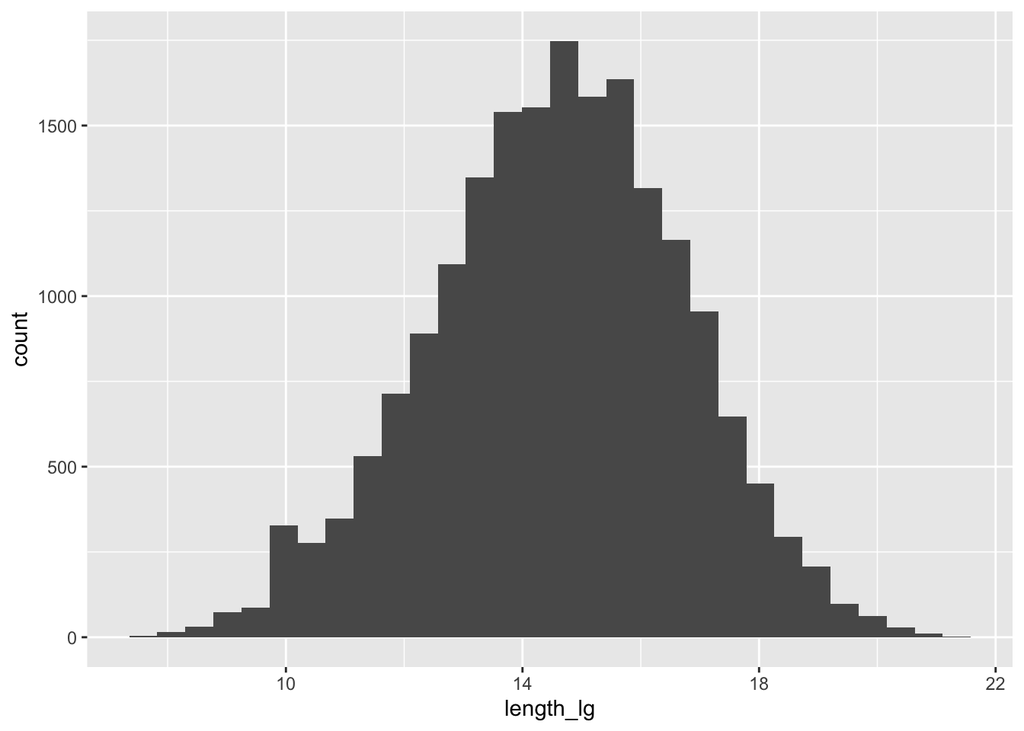

```r
NCBI_prot_final %>%
  mutate(length_lg = log2(length)) %>%
   ggplot(aes(x= length_lg)) +
   geom_histogram()
```

The NCBI protein coding genes be the basis of our genesis mint.

# 3 NFgenes main frame

The main frame will contain cleaned data from NCBI: Symbol, protein name, length, chromosome, start, end and strand. We will use the symbol as our primary ID.

Final data will be turned into JSON and exported

```r
NFgenes_main <- NCBI_prot_final

NFgenes_main_json <- toJSON(NFgenes_main)
```

# 4 Export

```r
write(NFgenes_main_json, "/Users/sebastianhesse/Documents/NFT_projects/NFgenes/R_files/compiled_data/NFgenes_main.json")
```